# Exercices Quarto

- Montrer tout le code
- Cacher tout le code
- Voir les sources

Auteur·rice

Affiliation

Michaël Delorme et PAOS

SSP/DéMéSIS/PAOS

Date de publication

14 octobre 2025

Modifié

13 octobre 2025

Exercices de la [formation R perfectionnement](https://ssm-agriculture.github.io/Formation-R-perf-03-quarto/), module Quarto, des [formations à R dispensées au SSM Agriculture](https://ssm-agriculture.github.io/site-formations-R/).

Pour bénéficier de la version la plus récente de Quarto, vous pouvez travailler –pour cette formation– sur la [version de pré-production de CERISE](https://rstudio-pprd.agriculture.rie.gouv.fr/).

```r
# ces paquets seront nécessaires pour la suite
library(readr)   # lecture des données
library(dplyr)   # manipulation des données
                 # et d'autres au fur et à mesure...
```

## 1 Découvrir l’interface

- `Fichier` > `Nouveau projet` > `Nouveau répertoire` > `Projet Quarto` >
- choisir un répertoire, par exemple : *formation* dans *~*
- moteur `knitr`

ou, dans un projet existant :

- `Fichier` > `Nouveau fichier` > `R Quarto document`

Basculer successivement sur l’éditeur texte brut / WYSIWYM[^1]

Tricoter le document

## 2 Produire un document simple

### 2.1 Formater du texte

- Nouveau document Quarto
- Insérer du [texte](https://fr.lipsum.com/feed/html)
- Insérer des titres de différent niveau
- Passer en gras, italique
- Insérer une image
- Faire une liste

Tricoter le document.

## 3 Code

### 3.1 Présentation des données

Utilisation d’un extrait randomisé du RA 2020. Ouvrir le fichier dans *donnees/ra_2020.rds*.

**Code**

```r
ra <- read_rds("donnees/ra_2020.rds")
```

**Aperçu**

```
Rows: 1,000
Columns: 11
$ siege_code_com <chr> "97128", "37178", "89436", "89143", "97103", "84087", "…
$ siege_lib_com  <chr> "LESCURE D ALBIGEOIS", "MARCOLES", "VALREAS", "RIOTORD"…
$ siege_dep      <chr> "51", "57", "11", "95", "34", "37", "971", "22", "16", …
$ siege_lib_dep  <chr> "VENDEE", "PAS DE CALAIS", "PYRENEES ATLANTIQUES", "PYR…
$ siege_reg      <chr> "52", "76", "53", "53", "32", "53", "44", "75", "03", "…
$ siege_lib_reg  <chr> "BOURGOGNE FRANCHE COMTE", "OCCITANIE", "NOUVELLE AQUIT…
$ geo_lct        <chr> "FR_CRS3035RES1000mN2888000E3883000", "FR_CRS3035RES100…
$ pbstot_coef17  <dbl> 2359.20, 3857.20, 478411.23, 15800.00, 213106.09, 14000…
$ otefda_coef17  <chr> "4600", "4600", "6184", "6184", "1516", "2829", "3500",…
$ sau_tot        <dbl> 108.99, 220.06, 0.00, 131.35, 275.92, 73.96, 94.03, 2.3…
$ ugbag_tot      <dbl> 0.00, 0.00, 167.28, 0.00, 0.00, 8.00, 40.62, 273.17, 3.…
```

### 3.2 Utiliser les résultats de calculs

- Insérer un code R chargeant les paquets nécessaires, ouvrant les données du RA et calculant la SAU totale
- Exécuter (sortie dans la console)
- Tricoter (aperçu HTML)

```r
ra |>
  summarise(sau_tot_ha = sum(sau_tot, na.rm = TRUE))
```

```
# A tibble: 1 × 1
  sau_tot_ha
       <dbl>
1     64986.
```

- Reprendre le code précédent, sauver le résultat dans une variable.
- Afficher le résultat au sein d’une phrase

```r
sau_tot_ha <- ra |>
  summarise(sau_tot_ha = sum(sau_tot, na.rm = TRUE)) |>
  pull(1)
```

> La SAU totale vaut 6.498577^{4} ha.
- Formater le résultat (arrondi, séparateur décimal, séparateur de milliers)

> La SAU totale vaut 64 985,8 ha.
- Utiliser des `options()` ou des `knitr::knit_hooks()` pour ne pas formater chaque sortie

```r
options(OutDec = ",",
        digits = 1,
        scipen = 1e3)

# ou par exemple
knitr::knit_hooks$set(inline = function(x) {
  if (!is.numeric(x)) {
    x
  } else {
    prettyNum(x, big.mark = " ")
  }
})
```

> La SAU totale vaut 64 986 ha.

### 3.3 Déboguer

- Exécuter chunk par chunk
- Utiliser “Exécuter tous les chunks au-dessus”.

## 4 Afficher des tableaux

Afficher les premières lignes du data.frame `ra`.

### 4.1 Tibble brut

```r
ra
```

Tableau 1

```
# A tibble: 1.000 × 11
   siege_code_com siege_lib_com  siege_dep siege_lib_dep siege_reg siege_lib_reg
   <chr>          <chr>          <chr>     <chr>         <chr>     <chr>
 1 97128          LESCURE D ALB… 51        VENDEE        52        BOURGOGNE FR…
 2 37178          MARCOLES       57        PAS DE CALAIS 76        OCCITANIE
 3 89436          VALREAS        11        PYRENEES ATL… 53        NOUVELLE AQU…
 4 89143          RIOTORD        95        PYRENEES ATL… 53        OCCITANIE
 5 97103          CAUMONT        34        HAUTE CORSE   32        AUVERGNE RHO…
 6 84087          AZY LE VIF     37        HAUTE SAVOIE  53        NOUVELLE AQU…
 7 40317          SOINGS EN SOL… 971       VIENNE        44        NORMANDIE
 8 12120          BONNAT         22        AVEYRON       75        AUVERGNE RHO…
 9 33389          MONTASTRUC LA… 16        CALVADOS      03        NOUVELLE AQU…
10 28111          OYRE           87        MAINE ET LOI… 76        BOURGOGNE FR…
# ℹ 990 more rows
# ℹ 5 more variables: geo_lct <chr>, pbstot_coef17 <dbl>, otefda_coef17 <chr>,
#   sau_tot <dbl>, ugbag_tot <dbl>
```

### 4.2 HTML mis en forme

Afficher les premières lignes du data.frame `ra` avec une mise en forme plus élaborée, avec {gt} ou `knitr::kable()`.

**gt**

```r
library(gt) # tableaux

ra |>
  slice_head(n = 5) |>
  gt()
```

| siege_code_com | siege_lib_com | siege_dep | siege_lib_dep | siege_reg | siege_lib_reg | geo_lct | pbstot_coef17 | otefda_coef17 | sau_tot | ugbag_tot |
| --- | --- | --- | --- | --- | --- | --- | --- | --- | --- | --- |
| 97128 | LESCURE D ALBIGEOIS | 51 | VENDEE | 52 | BOURGOGNE FRANCHE COMTE | FR_CRS3035RES1000mN2888000E3883000 | 2359 | 4600 | 109 | 0 |
| 37178 | MARCOLES | 57 | PAS DE CALAIS | 76 | OCCITANIE | FR_CRS3035RES1000mN2316000E3389000 | 3857 | 4600 | 220 | 0 |
| 89436 | VALREAS | 11 | PYRENEES ATLANTIQUES | 53 | NOUVELLE AQUITAINE | FR_CRS3035RES1000mN2316000E3562000 | 478411 | 6184 | 0 | 167 |
| 89143 | RIOTORD | 95 | PYRENEES ATLANTIQUES | 53 | OCCITANIE | FR_CRS3035RES1000mN2372000E4045000 | 15800 | 6184 | 131 | 0 |
| 97103 | CAUMONT | 34 | HAUTE CORSE | 32 | AUVERGNE RHONE ALPES | FR_CRS3035RES1000mN2540000E3823000 | 213106 | 1516 | 276 | 0 |

**knitr**

```r
library(knitr) # moteur de transfo markdown

ra |>
  slice_head(n = 5) |>
  kable()
```

| siege_code_com | siege_lib_com | siege_dep | siege_lib_dep | siege_reg | siege_lib_reg | geo_lct | pbstot_coef17 | otefda_coef17 | sau_tot | ugbag_tot |
| --- | --- | --- | --- | --- | --- | --- | --- | --- | --- | --- |
| 97128 | LESCURE D ALBIGEOIS | 51 | VENDEE | 52 | BOURGOGNE FRANCHE COMTE | FR_CRS3035RES1000mN2888000E3883000 | 2359 | 4600 | 109 | 0 |
| 37178 | MARCOLES | 57 | PAS DE CALAIS | 76 | OCCITANIE | FR_CRS3035RES1000mN2316000E3389000 | 3857 | 4600 | 220 | 0 |
| 89436 | VALREAS | 11 | PYRENEES ATLANTIQUES | 53 | NOUVELLE AQUITAINE | FR_CRS3035RES1000mN2316000E3562000 | 478411 | 6184 | 0 | 167 |
| 89143 | RIOTORD | 95 | PYRENEES ATLANTIQUES | 53 | OCCITANIE | FR_CRS3035RES1000mN2372000E4045000 | 15800 | 6184 | 131 | 0 |
| 97103 | CAUMONT | 34 | HAUTE CORSE | 32 | AUVERGNE RHONE ALPES | FR_CRS3035RES1000mN2540000E3823000 | 213106 | 1516 | 276 | 0 |

#### 4.2.1 Interactif

Afficher les 100 premières ligne de `ra` dans un tableau interactif Javascript avec datatable (package {DT}).

```r
library(DT) # tableaux interactifs

ra |>
  slice_head(n = 100) |>
  datatable(
    options = list(
      language = list(
        url = "https://cdn.datatables.net/plug-ins/1.10.11/i18n/French.json")))
```

Tableau 2

|  | siege_code_com | siege_lib_com | siege_dep | siege_lib_dep | siege_reg | siege_lib_reg | geo_lct | pbstot_coef17 | otefda_coef17 | sau_tot | ugbag_tot |
| --- | --- | --- | --- | --- | --- | --- | --- | --- | --- | --- | --- |
| 1 | 97128 | LESCURE D ALBIGEOIS | 51 | VENDEE | 52 | BOURGOGNE FRANCHE COMTE | FR_CRS3035RES1000mN2888000E3883000 | 2359.2 | 4600 | 108.99 | 0 |
| 2 | 37178 | MARCOLES | 57 | PAS DE CALAIS | 76 | OCCITANIE | FR_CRS3035RES1000mN2316000E3389000 | 3857.2 | 4600 | 220.06 | 0 |
| 3 | 89436 | VALREAS | 11 | PYRENEES ATLANTIQUES | 53 | NOUVELLE AQUITAINE | FR_CRS3035RES1000mN2316000E3562000 | 478411.23 | 6184 | 0 | 167.28 |
| 4 | 89143 | RIOTORD | 95 | PYRENEES ATLANTIQUES | 53 | OCCITANIE | FR_CRS3035RES1000mN2372000E4045000 | 15800 | 6184 | 131.35 | 0 |
| 5 | 97103 | CAUMONT | 34 | HAUTE CORSE | 32 | AUVERGNE RHONE ALPES | FR_CRS3035RES1000mN2540000E3823000 | 213106.09 | 1516 | 275.92 | 0 |
| 6 | 84087 | AZY LE VIF | 37 | HAUTE SAVOIE | 53 | NOUVELLE AQUITAINE | FR_CRS3035RES1000mN2482000E3924000 | 140000 | 2829 | 73.96 | 8 |
| 7 | 40317 | SOINGS EN SOLOGNE | 971 | VIENNE | 44 | NORMANDIE | FR_CRS3035RES1000mN2496000E4007000 | 589.96 | 3500 | 94.03 | 40.62 |
| 8 | 12120 | BONNAT | 22 | AVEYRON | 75 | AUVERGNE RHONE ALPES | FR_CRS3035RES1000mN2353000E3676000 | 12064.42 | 1516 | 2.31 | 273.17 |
| 9 | 33389 | MONTASTRUC LA CONSEILLERE | 16 | CALVADOS | 03 | NOUVELLE AQUITAINE | FR_CRS3035RES1000mN2901000E3895000 | 459538.97 | 4500 | 89.3 | 3.16 |
| 10 | 28111 | OYRE | 87 | MAINE ET LOIRE | 76 | BOURGOGNE FRANCHE COMTE | FR_CRS3035RES1000mN2782000E3520000 | 4976.47 | 5074 | 28.52 | 0 |

[output cut: 90 more lines]

## 5 Graphiques

- Ajouter un graphique dans le document Quarto. *Ex.* : Top 10 des SAU départementales à partir de `ra`.
- Préciser un titre de figure

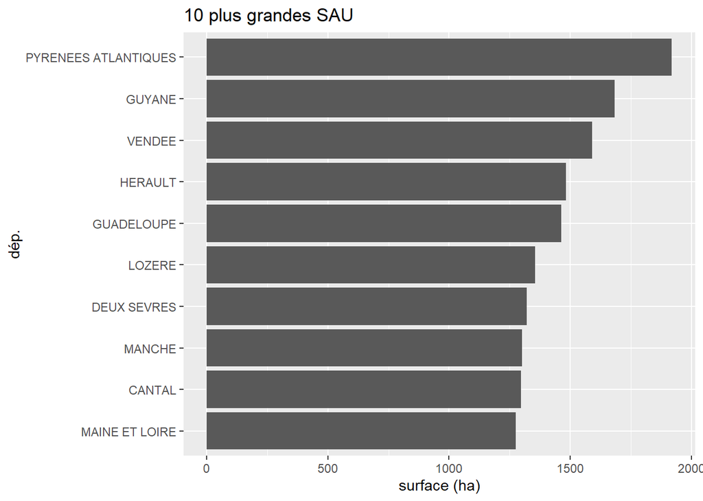

Figure 1 – SAU top 10

```r
library(ggplot2) # graphiques
library(forcats) # facteurs

graph_sau <- ra |>
  summarise(.by = c(siege_lib_dep),
          sau_dep_ha = sum(sau_tot, na.rm = TRUE),
          n = paste(n(), "exploit.")) |>
  slice_max(sau_dep_ha, n = 10) |>
  mutate(siege_lib_dep = fct_reorder(siege_lib_dep, sau_dep_ha)) |>
  ggplot(aes(siege_lib_dep,
             sau_dep_ha,
             text = n)) +
  geom_col() +
  coord_flip() +
  labs(title = "10 plus grandes SAU",
       x = "dép.",
       y = "surface (ha)")

graph_sau
```

Ajouter une phrase dans votre texte indiquant que la figure 1 montre des résultats intéressants (insertion d’un renvoi).

### 5.1 Interactivité

```r
library(plotly) # graphiques interactifs

graph_sau |>
  ggplotly(tooltip = "n")
```

[interactive chart not shown]

Figure 2 – SAU top 10 (interactive)

### 5.2 Disposition

Il est possible de choisir l’emprise et l’emplacement des graphiques (disponible aussi pour d’autres éléments).

- Placer un graphique en marge avec l’option `column:`.

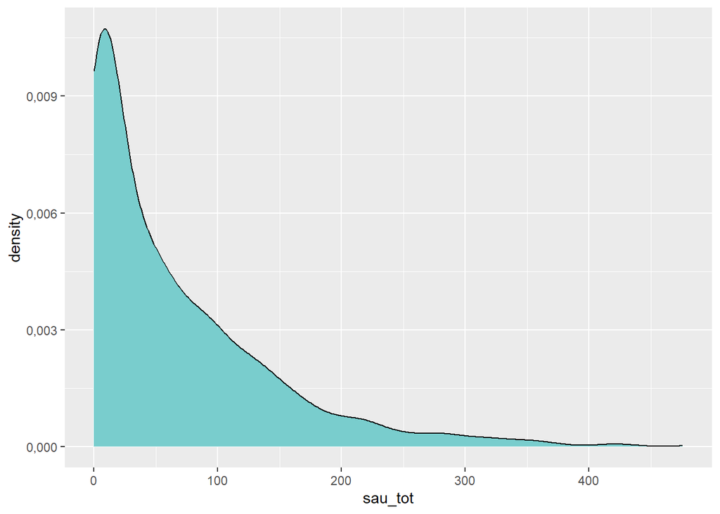

Figure 3 – Distribution de la SAU

```r
densite_sau <- ra |>
  ggplot() +
  geom_density(aes(sau_tot), fill = "darkslategray3")

densite_sau
```

[doc](https://quarto.org/docs/authoring/article-layout.html)

Par exemple : densité ou histogramme de la `sau_tot`.

- Disposer deux graphiques côte à côte avec l’option `layout-ncol:`.  
  Il est possible d’ajouter des sous-légendes pour chaque graphique [doc](https://quarto.org/docs/authoring/figures.html#complex-layouts)

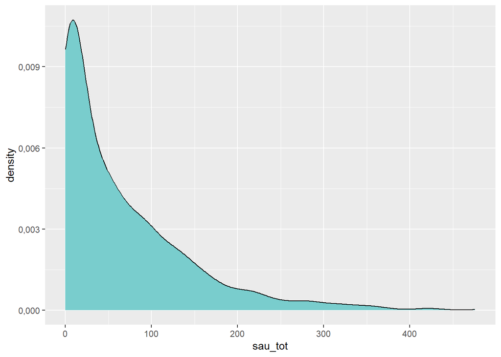

(a) Distribution

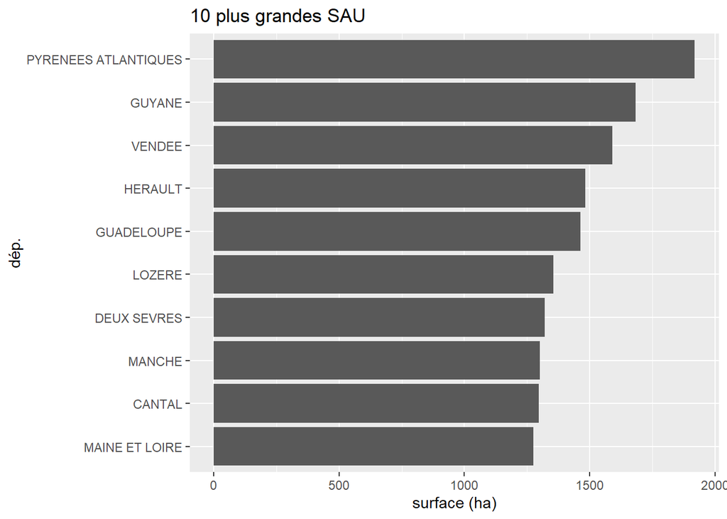

(b) Top 10

Figure 4 – SAU

```r
densite_sau
graph_sau
```

## 6 Cartes

Ouvrir la couche `region` du fichier *~/CERISE/03-Espace-de-Diffusion/000_Referentiels/0040_Geo/IGN/adminexpress/adminexpress_cog_simpl_000_2024.gpkg* et l’afficher avec {leaflet}.

```r
library(sf)      # SIG
library(leaflet) # cartographie dynamique

"donnees/adminexpress_cog_simpl_000_2024.gpkg" |>
  read_sf(layer = "region") |>
  leaflet() |>
  addTiles() |>
  addPolygons()
```

[interactive chart not shown]

Figure 5 – Carte

## 7 PDF

- Partir d’un nouveau document ou enlever les éléments interactifs {DT} ou {leaflet}
- Changer le format dans l’en-tête (`typst` ou `pdf`)
- Tricoter

## 8 Rapports paramétrés

- Faire un rapport régional donnant le nom de la région, la SAU, les UGB totaux.

## Méta

Ce document est produit par :  
*C:/Users/damien.dotta/DEMESIS/Formations_R/Formation_R_perfectionnement/Formation-R-perf-03-quarto/exercices/exercices_quarto.qmd*

## Dépôt Git

Ce projet est versionné dans :  
https://github.com/SSM-Agriculture/Formation-R-perf-03-quarto

## Notes de bas de page

[^1]: What You See Is What You Mean